# Tutorial 5: Trajectory Selection

## 4. Generate a trajectory ensemble

We draw a large NROY pool using `engine.get_nroy_samples(10000)` — this rejection-samples fresh candidates from the full prior against all trained emulators, cheaply and without running any new simulations. Each NROY point gets a unique seed so the trajectory is deterministic and reproducible.

```python
N_DAYS = obs_incidence.shape[0]

ensemble = []
for i, (_, row) in enumerate(nroy_samples.iterrows()):
    model = SIR(
        beta  = row['beta'],
        gamma = row['gamma'],
        s0    = POPULATION - SEED_INFECTIONS,
        i0    = SEED_INFECTIONS,
        seed  = i,   # unique seed per NROY point
    )
    inc = model.get_incidence()
    ensemble.append({
        'beta':      row['beta'],
        'gamma':     row['gamma'],
        'seed':      i,
        'incidence': inc[:N_DAYS],
    })

ensemble_df = pd.DataFrame(ensemble)
print(f"Ensemble size: {len(ensemble_df)} trajectories (1 per NROY sample)")
```

```
Ensemble size: 10000 trajectories (1 per NROY sample)
```

```python
inc_matrix = np.vstack(ensemble_df['incidence'].values)  # shape (n_traj, n_days)

# Compute calibration features for every trajectory
ensemble_df['peak']  = inc_matrix.max(axis=1)
ensemble_df['ar']    = inc_matrix.sum(axis=1) / POPULATION
ensemble_df['inc5']  = inc_matrix[:, 5]

fig, axs = plt.subplots(2, 2, figsize=(14, 8))

# Top-left: time-series spaghetti with day 5 highlighted
ax = axs[0, 0]
for row in inc_matrix:
    ax.plot(row, color='steelblue', alpha=0.05, lw=0.8)
ax.plot(inc_matrix.mean(axis=0), color='steelblue', lw=2, label='Ensemble mean')
ax.plot(obs_incidence.values, 'ko-', ms=4, lw=2, label='Observed', zorder=5)
ax.scatter([5], [obs_inc5], s=120, facecolors='none', edgecolors='red',
           linewidths=2, zorder=6, label='Emulated day 5')
ax.set_xlabel('Day')
ax.set_ylabel('Daily new cases')
ax.set_title(f'Prior NROY ensemble ({len(ensemble_df):,} trajectories)')
ax.legend(fontsize=8)
ax.grid(ls=':')

# Top-right: peak incidence
ax = axs[0, 1]
ax.hist(ensemble_df['peak'], bins=30, color='steelblue', alpha=0.6, edgecolor='white')
ax.axvline(obs_peak, color='red', lw=2, ls='--', label=f'Observed ({obs_peak:.0f})')
ax.axvspan(obs_peak * (1 - 1.96 * 0.05), obs_peak * (1 + 1.96 * 0.05),
           color='red', alpha=0.08, label='HM tolerance (±5%)')
ax.set_xlabel('Peak incidence')
ax.set_ylabel('Count')
ax.set_title('Peak incidence')
ax.legend(fontsize=8)
ax.grid(ls=':')

# Bottom-left: attack rate
ax = axs[1, 0]
ax.hist(ensemble_df['ar'], bins=30, color='steelblue', alpha=0.6, edgecolor='white')
ax.axvline(obs_ar, color='red', lw=2, ls='--', label=f'Observed ({obs_ar:.2f})')
ax.axvspan(obs_ar * (1 - 1.96 * 0.03), obs_ar * (1 + 1.96 * 0.03),
           color='red', alpha=0.08, label='HM tolerance (±3%)')
ax.set_xlabel('Attack rate')
ax.set_ylabel('Count')
ax.set_title('Attack rate')
ax.legend(fontsize=8)
ax.grid(ls=':')

# Bottom-right: incidence day 5
ax = axs[1, 1]
ax.hist(ensemble_df['inc5'], bins=30, color='steelblue', alpha=0.6, edgecolor='white')
ax.axvline(obs_inc5, color='red', lw=2, ls='--', label=f'Observed ({obs_inc5:.0f})')
ax.axvspan(obs_inc5 * (1 - 1.96 * 0.10), obs_inc5 * (1 + 1.96 * 0.10),
           color='red', alpha=0.08, label='HM tolerance (±10%)')
ax.set_xlabel('Incidence day 5')
ax.set_ylabel('Count')
ax.set_title('Incidence day 5')
ax.legend(fontsize=8)
ax.grid(ls=':')

fig.suptitle('Prior NROY ensemble vs HM targets', fontsize=12)
fig.tight_layout()
```

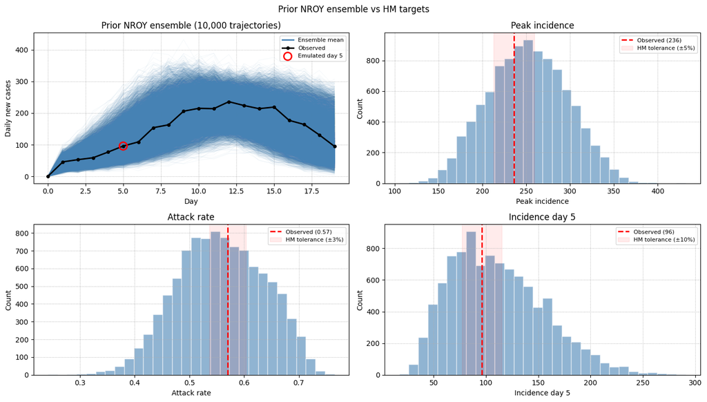